# Homework #2

### Question 5: The table compares GDP (Gross Domestic Product) per Capita to Life Satisfaction: definitions of both are below. The goal is to explore the relationship between money and happiness. Life Satisfaction scaled from 0 to 10 with zero being the least and 10 being best satisfied. GDP per Capita for 2015 provided by International Monetary Fund. The gross domestic product of a nation divided by population of that nation.

### (a). What is the response and the explanatory variable in this setting?

### The response variable is level of happiness and the explanatory variable is GDP

### (b). Make a scatter plot of the data and comment on the relationship

```r
read.csv(file = "GDP_vs_Satisfaction.csv")
```

| Country | GDP | Satisfaction |
| --- | --- | --- |
| Australia | 50962 | 7.3 |
| Austria | 43724 | 7.0 |
| Belgium | 40107 | 6.9 |
| Canada | 43332 | 7.3 |
| Chile | 13341 | 6.7 |
| Czech Republic | 17257 | 6.6 |
| Denmark | 52114 | 7.5 |
| Estonia | 17288 | 5.6 |
| Finland | 41974 | 7.5 |
| France | 37675 | 6.4 |

[output cut: 25 more lines]

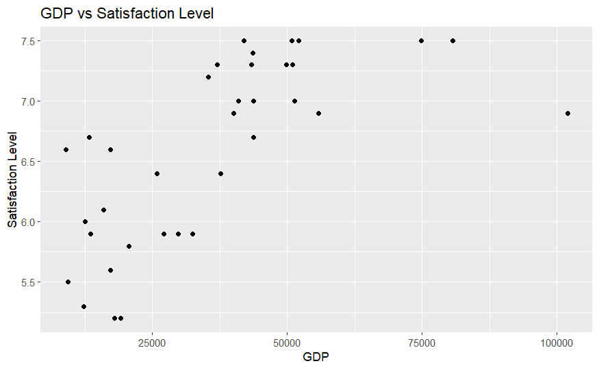

```r
gdp_satisfaction <- read.csv(file = "GDP_vs_Satisfaction.csv")
ggplot(gdp_satisfaction, aes(x = GDP, y = Satisfaction)) + geom_point() + labs(x = "GDP", y = "Satisfaction Level", title = "GDP vs Satisfaction Level")
```

### There seems to be a moderate positive correlation between the two variables along with an outlier

### (c). Calculate the sample correlation between the two variables

```r
cor(gdp_satisfaction$GDP, gdp_satisfaction$Satisfaction)
```

```
[1] 0.6873774
```

### (d). Regardless of you opinion in part (b), fit a simple linear regression model to this data. Show the R output of the SLR fit and the scatterplot with fitted line overlaid

[output not shown]

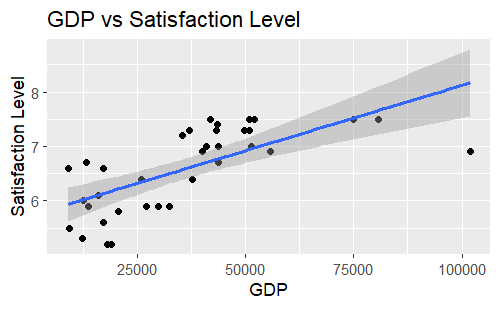

```r
ggplot(gdp_satisfaction, aes(x = GDP, y = Satisfaction)) + geom_point() + geom_smooth(method = "lm") + labs(x = "GDP", y = "Satisfaction Level", title = "GDP vs Satisfaction Level")
```

### (e). What is the coefficient of determination for the model. Interpret this value in the context of the problem

```r
gdp.lm = lm(GDP ~ Satisfaction, data = gdp_satisfaction)
summary(gdp.lm)$r.squared
```

```
[1] 0.4724877
```

### (f). In the original data, observation number 21 (“Luxembourg”) seems to be an outlier. Use the below code line to remove that observation from the dataset. Then re-fit the regression model to the reduced dataset. Include the R output and the scatterplot of the reduced data with fitted model overlaid

[output not shown]

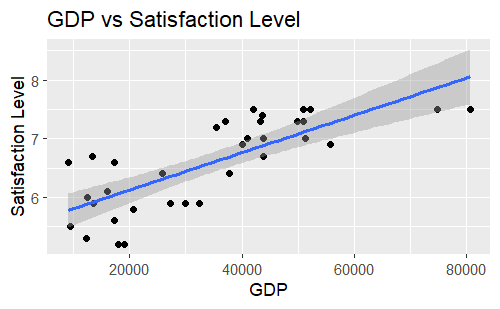

```r
gdp_satisfaction_new <- gdp_satisfaction[-21,]
ggplot(gdp_satisfaction_new, aes(x = GDP, y = Satisfaction)) + geom_point() + geom_smooth(method = "lm") + labs(x = "GDP", y = "Satisfaction Level", title = "GDP vs Satisfaction Level")
```

### (g). Does it seem like the model fit has improved once “Luxembourg” was removed form the dataset. Explain.

```r
gdp.lm = lm(GDP ~ Satisfaction, data = gdp_satisfaction_new)
summary(gdp.lm)$r.squared
```

```
[1] 0.5941686
```

### Yes because the coefficient of determination increased, making the relationship between the two variables stronger